# LHS Example

Marisa Eisenberg

10/25/2017

### Load Packages

We’ll use the `lhs` package to do latin hypercube sampling:

```r
library(lhs)
library(deSolve)
library(ggplot2)
library(gridExtra)
```

### Latin Hypercube Sampling (LHS)

Let’s try a few different samplers and see how they look. Try the code below with several of the methods in the documentation, e.g. `randomLHS`,`geneticLHS`,`improvedLHS`, and `optimumLHS`. Do you notice any differences? Also try out the code for 1000 samples instead of 100—are any of the methods faster/slower than others?

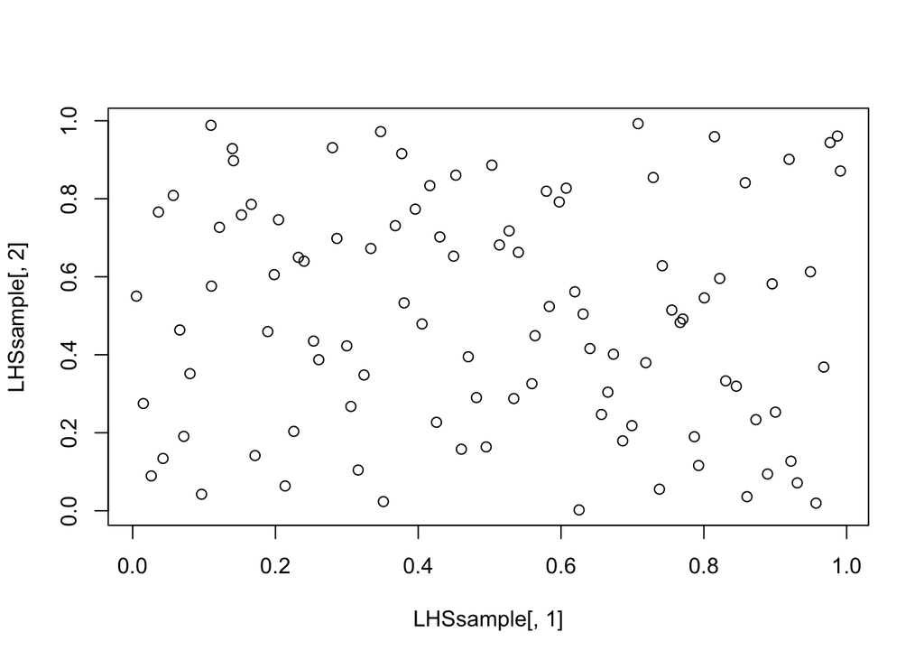

```r
set.seed(8)
LHSsample = randomLHS(100,2)
plot(LHSsample[,1],LHSsample[,2])
```

### LHS for an SIR Model

Now, let’s start using LHS to look at how an SIR model behaves over a range of parameter space. We’ll start by setting up our SIR model, and including some data to work with:

```r
# Data set
times = c(0, 7, 14, 21, 28, 35, 42, 49, 56, 63, 70, 77, 84, 91, 98)
data = c(97, 271, 860, 1995, 4419, 6549, 6321, 4763, 2571, 1385, 615, 302, 159, 72, 34)

# Model function
SIRode <- function(t, x, params){
  S = x[1]
  I = x[2]
  R = x[3]

  b = params[1]
  g = params[2]

  dS = -b*S*I
  dI = b*S*I - g*I
  dR = g*I

  list(c(dS, dI, dR))
}

# Extra model setup - default parameters, initial conditions, measurement equation
params = c('beta'=0.4,'gamma'=0.25, 'kappainv'=1/80000)
x0fun = function(cases,params) {
  x0 = c(1-(10*params[3]), 10*params[3], 0) # suppose we start with 10 cases
  names(x0) = c('S0','I0','R0')
  x0}
yfun = function(odeSim, params){odeSim[,3]/params[3]}
```

Now that we have a model, let’s generate a Latin hypercube sample for the parameters. The `lhs` package generates samples over the range (0,1), but we can rescale that to match the parameter ranges (see below).

```r
numsamples = 1500
paramsample = randomLHS(numsamples,length(params))
```

First, let’s just verify that our samples do indeed appear uniform for each of the parameters:

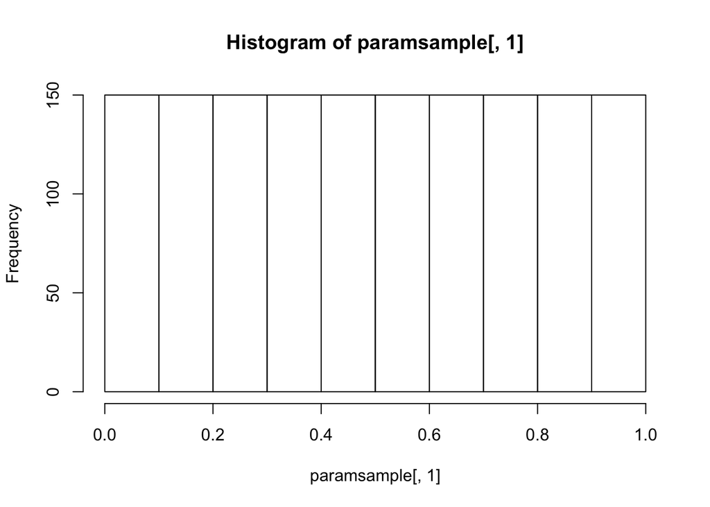

```r
hist(paramsample[,1])
```

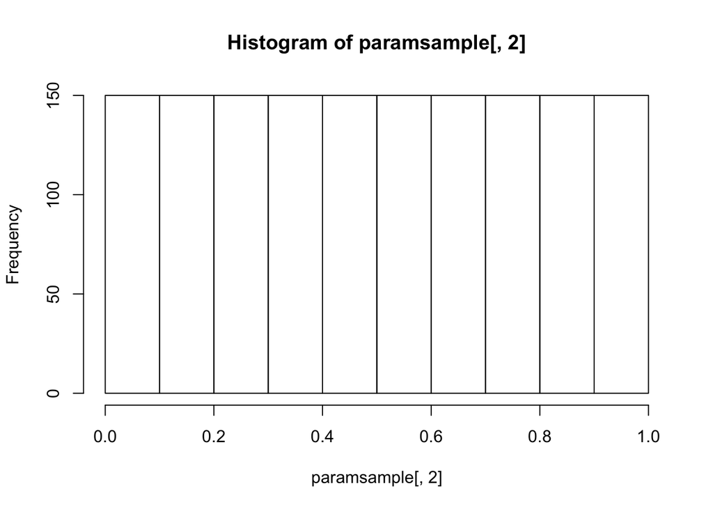

```r
hist(paramsample[,2])
```

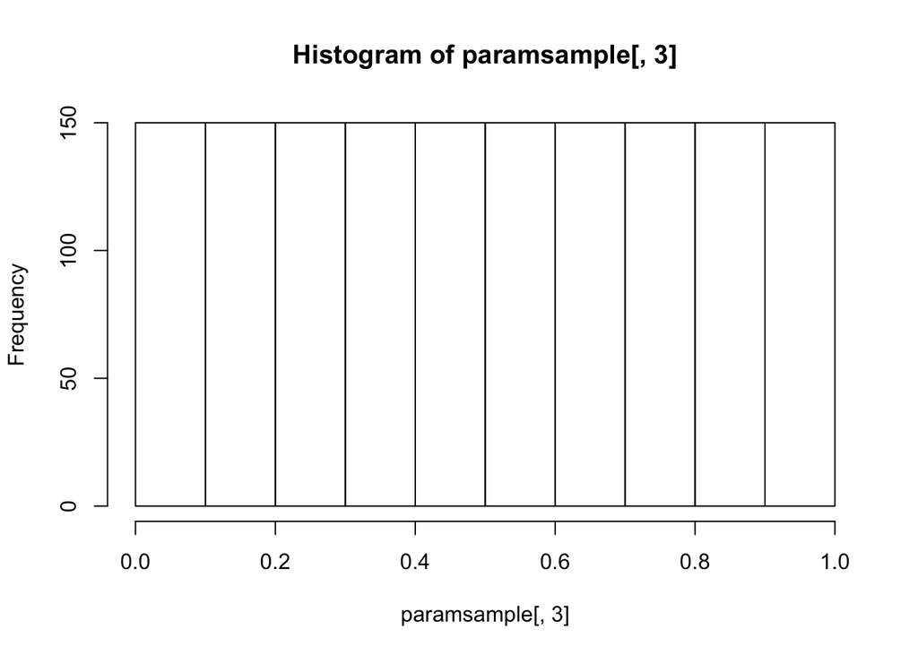

```r
hist(paramsample[,3])
```

Yep, looks pretty uniform!

#### Evaluating the model across parameter space

Now, let’s evaluate how a few different quantities of interest across parameter space—R0, the epidemic trajectory, and the goodness-of-fit (negative log likelihood). Let’s calculate the quantities of interest for each of the sampled parameter values:

```r
# these are containers that we'll fill in
ysample = matrix(NA,length(times),numsamples)
nllsample = numeric(numsamples)
R0sample = numeric(numsamples)

# set upper and lower bounds for the parameters - order is beta, gamma, kappainv
paramlower = c(0,0.1,1/100000)
paramupper = c(1,0.5,1/10000)

# calculate each quantity for each sampled parameter set
for(i in 1:numsamples){
  # We need to re-scale the parameters to be in the upper and lower bounds above
  ptemp = paramlower + (paramupper-paramlower)*paramsample[i,]

  xtemp <- ode(x0fun(cases,ptemp), times, SIRode, ptemp, method='ode45')
  ysample[,i] = yfun(xtemp,ptemp)

  nllsample[i] =  sum(yfun(xtemp,ptemp)) - sum(data*log(yfun(xtemp,ptemp)))

  R0sample[i] = ptemp[1]/ptemp[2] #R0 = beta/gamma
}
```

#### $R_0$ across parameter space

We can start by looking at $R_0$ as a function of the parameters—let’s look at $\beta$ and $\gamma$:

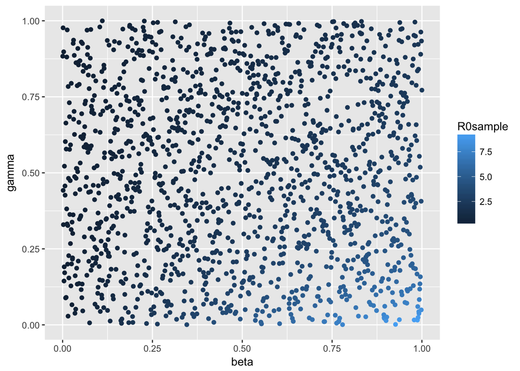

```r
ggplot(cbind.data.frame(paramsample,nllsample), aes(x = paramsample[,1],y = paramsample[,2],color = R0sample)) + geom_point() + labs(x="beta", y="gamma")
```

Are these patterns consistent with what you would expect?

Next, let’s look at how specific ranges of $R_0$ cluster in parameter space. We’ll take the following quantiles of our $R_0$ sample:

```r
R0quantiles = quantile(R0sample, probs=c(0.25,0.5,0.75,0.9), na.rm=TRUE)

# colors for plotting
pcolors = c("#555555","#777777","#AAAAAA","#EEEEEE")
```

One way to look at this is to plot color-coded histograms:

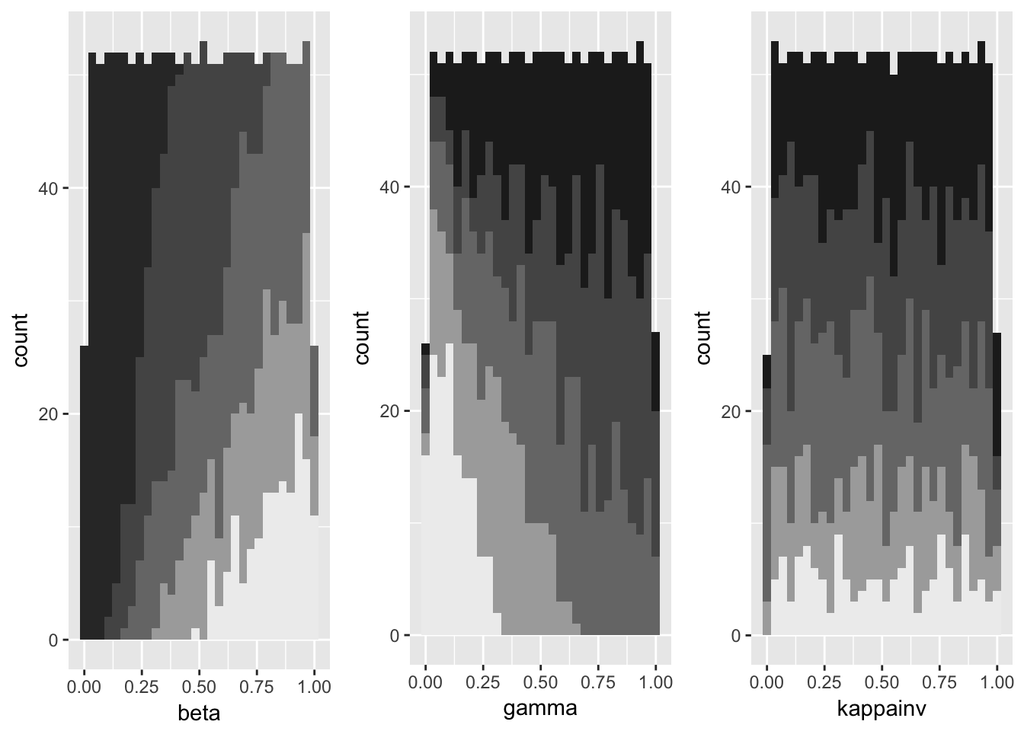

```r
# Generate the basic histogram for each parameter, over all samples
betaR0plot = ggplot(as.data.frame(paramsample), aes(paramsample[,1])) +
    geom_histogram(fill="#333333") +
    labs(x="beta")

gammaR0plot = ggplot(as.data.frame(paramsample), aes(paramsample[,2])) +
    geom_histogram(fill="#222222") +
    labs(x="gamma")

kR0plot = ggplot(as.data.frame(paramsample), aes(paramsample[,3])) +
    geom_histogram(fill="#222222") +
    labs(x="kappainv")

# Loop over each quantile and add it to the plot
for(i in 1:4){
  pR0temp = paramsample[which(R0sample >= R0quantiles[i]),] #pull just that quantile

  # add it to the plots
  betaR0plot = betaR0plot + geom_histogram(data = as.data.frame(pR0temp),aes(V1),fill = pcolors[i])
  gammaR0plot = gammaR0plot + geom_histogram(data = as.data.frame(pR0temp),aes(V2),fill = pcolors[i])
  kR0plot = kR0plot + geom_histogram(data = as.data.frame(pR0temp),aes(V3),fill = pcolors[i])
}

# print the plot
grid.arrange(betaR0plot, gammaR0plot, kR0plot, ncol=3)
```

#### Examining the negative log likelihood

We might also want to look at how the model behavior changes over parameter space, and one way to look at that is by evaluating the goodness of fit for different trajectories.

First, let’s look at a histogram of the goodness of fit:

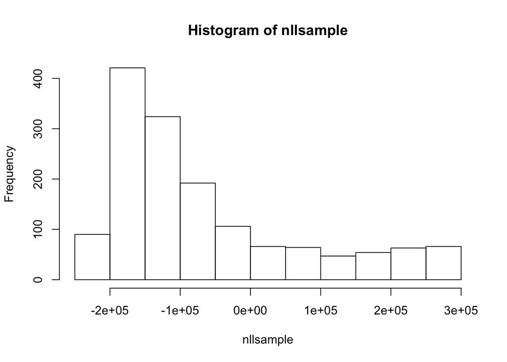

```r
hist(nllsample)
```

We can also plot the model behavior as a function of the goodness of fit:

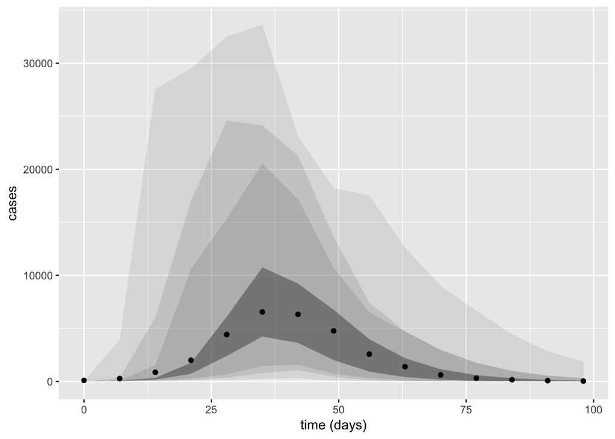

```r
# quantiles of the -LL that we'll look at (best 25%, 10%, 5%, 1%)
quantiles = quantile(nllsample, probs=c(0.25,0.1,0.05,0.01), na.rm=TRUE)

ycolors = c("#88888826","#66666626","#55555526","#44444477")

yplot = ggplot(cbind.data.frame(times,data),aes(x=times,y=data))

for(i in 1:4){
  ytemp = ysample[,which(nllsample <= quantiles[i])]
  tempdata = cbind.data.frame('ytemp.min' = apply(ytemp, 1, min), 'ytemp.max' = apply(ytemp, 1, max))

  yplot = yplot + geom_ribbon(data = tempdata, aes(min=ytemp.min, max=ytemp.max), fill = ycolors[i])
}

yplot = yplot + geom_point(color = rgb(0,0,0)) + labs(x="time (days)", y="cases")
print(yplot)
```

Lastly, adapt the code from the $R_0$ section to instead plot how the negative log likelihood varies as a function of the parameters (i.e. regenerate the colored scatterplot and 3-panel histogram but using the $-LL$ as the quantity of interest).